# Neginhib Diffusion Models

Ann E. Nordmeyer

Analysis for Neginhib (Ann Nordmeyer, Erica Yoon, Mike Frank). The study included three games designed to test the relationship between inhibitory control, implicature processing, and negation processing. All games had a similar structure: participants saw two pictures and heard a word, and had to select the picture that goes with the word as quickly as possible. Each game had two trial types, labeled *control* and *target* in these analyses. The three games were:

**Inhibition Game** : Participants saw several identical trials in a row (e.g. the word “apple” with pictures of an apple and a cookie) and then saw a trial with the same pictures but a different word (e.g. “cookie” with pictures of an apple and a cookie). The repeated trials in each run are the *control* trials and the final trial in each run was the *target* trial, designed to measure inhibitory control.

**Implicature Game**: On *control* / unambiguous trials, participants saw two single pictures (e.g. a picture of an apple and a picture of a cookie) and heard a word referring to one of the pictures (e.g. “apple”). On *target* / implicatures trials, participants saw a picture with a single item and a picture with the same item paired with another item (e.g. a picture of an apple, and a picture of an apple and a cookie) and heard e.g. “apple”. The “correct” response on these trials is the response generated by the ad-hoc implicature, e.g. that “apple” must refer to the single apple because otherwise the speaker would have said “cookie”.

**Negation Game**: On *control* / positive trials, participants saw two pictures and heard a word referring to one of the pictures (e.g. a picture of an apple and a picture of a cookie, with the word “apple”). On *target* / negative trials, participants saw two pictures and heard a word negating one of the pictures (e.g. a picture of an apple and a picture of a cookie, with the words “no apple”).

Kids played these games at Bing on an iPad (only 4-year-olds) or at the CDM on a computer (4, 5, and 6-year-olds), with 60 trials per game in both the iPad and the computer version. Adults completed the task on MTurk, with 120 trials per game. The adult version of the task can be viewed here: https://langcog.stanford.edu/expts/EJY/neginhib/v1/turk/neginhib_mturk.html

# Setting up

Load required Libraries

```r
rm(list=ls())
library(ggplot2)
library(dplyr)
library(tidyr)
library(magrittr)
#library(directlabels)
library(RWiener)
library(knitr)
library(bootstrap)
library(gridExtra)
library(effsize)
```

Some useful functions:

```r
# number of unique subs
n.unique <- function (x) {
  length(unique(x))
}

# for bootstrapping 95% confidence intervals
theta <- function(x,xdata) {mean(xdata[x])}
ci.low <- function(x) {
  quantile(bootstrap(1:length(x),1000,theta,x)$thetastar,.025)}
ci.high <- function(x) {
  quantile(bootstrap(1:length(x),1000,theta,x)$thetastar,.975)}
```

Load in data

```r
d.turk <- read.csv("../long_data/long_data_mturk.csv")
n.turk.initial <- n.unique(d.turk$subid)

d.turk <- d.turk %>%
  # remove anyone who played fewer than 300 trials (means they did not complete at least half of the third game) or over 408 trials (means they completed the task twice, because 408 is max number of trials -- this only happened for one participant and I'm not sure how they were able to do this, so I'm rejecting them)
  group_by(subid) %>%
  mutate(ntrials = n()) %>%
  filter(ntrials > 300 & ntrials < 408) %>%
  ungroup() %>%
  # create resp and rt vars
  mutate(resp = factor(response, levels=c("Y","N"), labels=c("upper","lower")),
         q = rt/1000) %>%
  # remove outlier RTs
  filter(rt > 0) %>% # filtering the mysterious neg rt...
  filter(log(rt) < mean(log(rt) + 2 * sd(log(rt))),
         log(rt) > mean(log(rt) - 2 * sd(log(rt)))) %>%
  # clean up
  select(subid, game, trial.num, trial.type, q, resp) %>%
  mutate(location = "turk",
         modality = "computer",
         agegroup = "adults") %>%
  ungroup()
n.turk.final <- n.unique(d.turk$subid)

d.bing <- read.csv("../long_data/long_data_bing.csv") %>%
  filter(agegroup == 4)
n.bing.initial <- n.unique(d.bing$subid)

d.bing <- d.bing %>%
  # remove any child who played fewer than 150 trials (means they didn't complete at least half of the final game)
  group_by(subid) %>%
  mutate(ntrials = n()) %>%
  filter(ntrials > 150) %>%
  ungroup() %>%
  # create resp and rt vars
  mutate(resp = factor(response, levels=c("Y","N"), labels=c("upper","lower")),
         q = rt/1000) %>%
  # remove outlier RTs
  filter(rt > 0) %>% # filtering the mysterious neg rt...
  filter(log(rt) < mean(log(rt) + 2 * sd(log(rt))),
         log(rt) > mean(log(rt) - 2 * sd(log(rt))))
m_age_4ipad <- mean(d.bing$age)
min_age_4ipad <- min(d.bing$age)
max_age_4ipad <- max(d.bing$age)

d.bing <- d.bing %>%
  # clean up
  select(subid, agegroup, game, trial.num, trial.type, q, resp) %>%
  mutate(location = "preschool",
         modality = "iPad") %>%
  ungroup()
n.bing.final <- n.unique(d.bing$subid)

d.cdm <- read.csv("../long_data/long_data_cdm.csv") %>%
  filter(agegroup == 4 | agegroup == 5 | agegroup == 6)
n.cdm.initial <- n.unique(d.cdm$subid)

d.cdm <- d.cdm %>%
  # remove any child who played fewer than 150 trials (means they didn't complete at least half of the final game)
  group_by(subid) %>%
  mutate(ntrials = n()) %>%
  filter(ntrials > 150) %>%
  ungroup() %>%
  group_by(agegroup) %>% #Note: doing rt trimming within age group for this sample
  # create resp and rt vars
  mutate(resp = factor(response, levels=c("Y","N"), labels=c("upper","lower")),
         q = rt/1000) %>%
  # remove outlier RTs
  filter(rt > 0) %>% # filtering the mysterious neg rt...
  filter(log(rt) < mean(log(rt) + 2 * sd(log(rt))),
         log(rt) > mean(log(rt) - 2 * sd(log(rt)))) %>%
  ungroup()
m_age_comp <- aggregate(age ~ agegroup, d.cdm, mean)
min_age_comp <- aggregate(age ~ agegroup, d.cdm, min)
max_age_comp <- aggregate(age ~ agegroup, d.cdm, max)

d.cdm <- d.cdm %>%
  # clean up
  select(subid, agegroup, game, trial.num, trial.type, q, resp) %>%
  mutate(location = "museum",
         modality = "computer") %>%
  ungroup()
n.cdm.final <- n.unique(d.cdm$subid)
ns.cdm <- aggregate(subid ~ agegroup, d.cdm, n.unique)

d <- rbind(d.turk, d.bing, d.cdm)

d$subid <- factor(d$subid)
d$location <- factor(d$location)
d$modality <- factor(d$modality)
d$agegroup <- factor(d$agegroup)
d$agegroup_modality <- factor(paste(d$agegroup, d$modality, sep = "_"), levels = c("4_iPad", "4_computer", "5_computer", "6_computer", "adults_computer"))
d$trial.type <- factor(d$trial.type, levels = c("control", "inhib", "unambiguous", "implicature", "positive", "negative"))
```

We excluded 2 adult participants, 1 child iPad participants (Bing), and 1 child computer participants (CDM) for failing to complete at least half of the trials in each game. This left a final sample of 48 adult participants, 19 child iPad participants (Bing), and 66 child computer participants (CDM).

The iPad/bing sample ranged in age from 4.04 to 4.99, with a mean age of 4.54. The computer/cdm sample included 22 4-year-olds (age range 4.01-4.99, mean age = 4.6), 19 5-year-olds (age range 5.03-5.95, mean age = 5.49), and 25 6-year-olds (age range 6-6.99, mean age = 6.46).

# Initial analysis

## Proportion Correct

Proportion correct:

```
## ymax not defined: adjusting position using y instead
## ymax not defined: adjusting position using y instead
## ymax not defined: adjusting position using y instead
```

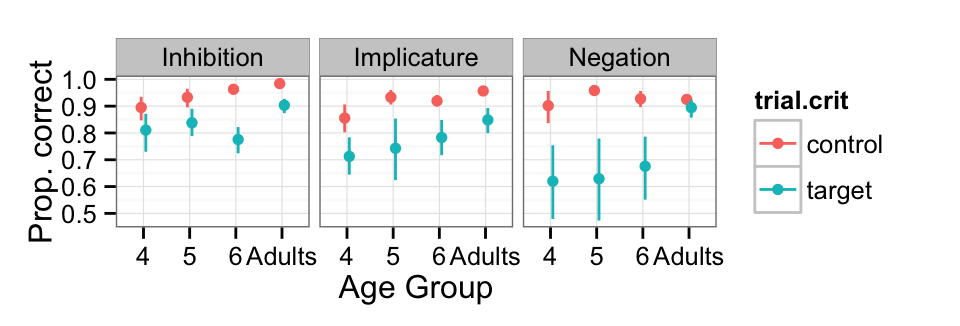

```r
d$correct <- as.numeric(as.character(factor(d$resp, levels=c("upper","lower"), labels=c("1","0"))))==1
d$trial.crit <- factor(d$trial.type %in% c("inhib","implicature","negative"),
                       levels = c(FALSE, TRUE),
                       labels = c("control","target"))
d$game <- factor(d$game, levels=c("inhibition","implicature","negation"))

ms <- d %>%
  filter(modality == "computer") %>%
  group_by(game, trial.crit, subid, agegroup) %>%
  summarise(m = mean(correct)) %>%
  group_by(game, trial.crit, agegroup) %>%
  summarise(cih = ci.high(m),
            cil = ci.low(m),
            m = mean(m))
ms$agegroup <- factor(ms$agegroup, levels = c("4", "5", "6", "adults"), c("4", "5", "6", "Adults"))
ms$game <- factor(ms$game, labels = c("Inhibition", "Implicature", "Negation"))

qplot(data=ms, x=agegroup, y=m, color=trial.crit,
      geom="point", position=position_dodge(.2)) +
  geom_errorbar(aes(ymin=cil, ymax=cih),
                position=position_dodge(.2), width=0) +
  facet_grid( ~ game) +
  ylab("Prop. correct") + xlab("Age Group") +
  scale_fill_hue(name="Trial Type") +
  theme_bw()
```

So kids are much less accurate than adults on target trials, especially in the implicature and negation games. It looks like 4-year-olds are a little more accurate on the computer, and children show some improvement on the implicatures game across development but maybe not so much improvement across development on the negation game?

## Reaction time

What about reaction time? Here we just look at RTs on correct trials (outlier RTs were trimmed earlier when the data was loaded).

```
## ymax not defined: adjusting position using y instead
## ymax not defined: adjusting position using y instead
## ymax not defined: adjusting position using y instead
```

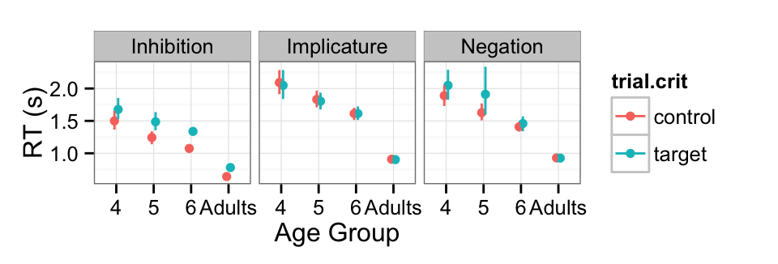

```r
#Plot data
ms <- d %>%
  filter(correct == TRUE, modality == "computer") %>%
  group_by(game, trial.crit, subid, agegroup) %>%
  summarise(m = mean(q)) %>%
  group_by(game, trial.crit, agegroup) %>%
  summarise(cih = ci.high(m),
            cil = ci.low(m),
            m = mean(m))
ms$agegroup <- factor(ms$agegroup, levels = c("4", "5", "6", "adults"), labels = c("4", "5", "6", "Adults"))
ms$game <- factor(ms$game, labels = c("Inhibition", "Implicature", "Negation"))
#kable(summary(xflips.exp1)$coefficients, digits = 3)

qplot(data=ms, x=agegroup, y=m, color=trial.crit,
      geom="point", position=position_dodge(.2)) +
  geom_errorbar(aes(ymin=cil, ymax=cih),
                position=position_dodge(.2), width=0) +
  facet_grid( ~ game) +
  ylab("RT (s)") + xlab("Age Group") +
  scale_fill_hue(name="Trial Type") +
  theme_bw()
```

So it looks like for both adults and children there is only an effect of trial type (e.g. control vs. target) on the inhibition game, where both adults and children were slower on the target trials. 4-year-olds were much faster on the iPad than on the computer, which is good to know!

# Diffusion Analysis

For the diffusion analysis, we estimated parameters separately for each condition within each game. Parameters are estimated within each subject and then we aggregate across subjects to get means & confidence intervals on the parameters.

## Plot densities

Plots show density of RTs for correct (pink) and incorrect responses (green), for each trial type. You can kind of see the speed-accuracy tradeoff in some of these plots, especially the inhibition trials. Also, it is clear that children are generally much more prone to fast errors.

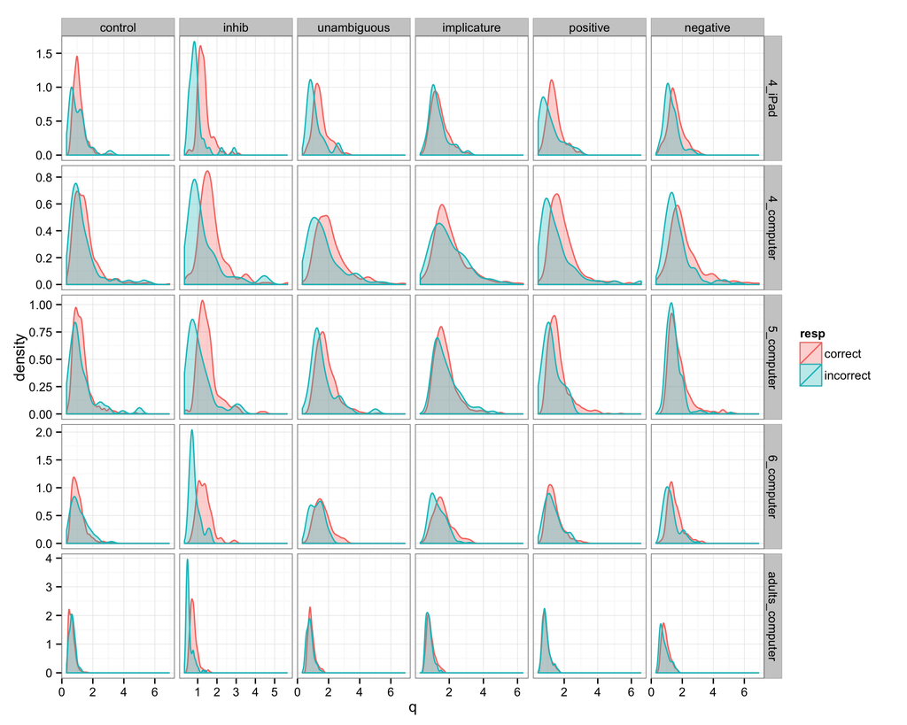

```r
#Make a bunch of plots:
ggplot(d, aes(x=q)) +
  geom_density(aes(group=resp, colour=resp, fill=resp), alpha=0.3) +
  facet_grid(agegroup_modality ~ trial.type, scales = "free") +
  scale_fill_hue(labels = c("correct", "incorrect")) +
  scale_color_hue(labels = c("correct", "incorrect")) +
  theme_bw()
```

## Estimating parameters

Calculate parameters for each condition separately, within each subject. Then aggregate across subjects to get means & confidence intervals on the parameters, and plot the parameters across each game & condition.

```r
sub.pars <- data.frame(Separation = numeric(),
                       Non.Decision = numeric(),
                       Bias = numeric(),
                       Drift = numeric(),
                       Trial.Type = character(),
                       SubID = character(),
                       Age = character(),
                       Modality = character())
sub.pars$Trial.Type <- as.character(sub.pars$Trial.Type)
sub.pars$SubID <- as.character(sub.pars$SubID)
sub.pars$Age <- as.character(sub.pars$Age)
sub.pars$Modality <- as.character(sub.pars$Modality)

temp.pars <- sub.pars

#because RWiener is finicky:
d$resp <- as.character(d$resp)
```

```r
trialtypes <- c("control", "inhib", "unambiguous", "implicature", "positive", "negative")
subs <- unique(d$subid)

for (j in 1:length(subs)) {
  sid <- as.character(subs[j])
  for (i in 1:length(trialtypes)) {
    ttype <- as.character(trialtypes[i])
    dat <- as.data.frame(subset(d, trial.type == ttype & subid == sid))
    opt <- optim(c(1, .1, .1, 1), wiener_deviance,
                 dat=select(dat, c(q, resp)), method="Nelder-Mead")
    pars <- c(opt$par, ttype, sid, as.character(dat$agegroup[1]), as.character(dat$modality[1]))
    temp.pars[i,] <- pars
  }
  sub.pars <- rbind(temp.pars, sub.pars)
  temp.pars <- temp.pars[0, ]
}
```

### Parameter plot 1 (terrible):

First plot the difference between parameters between conditions in different games:

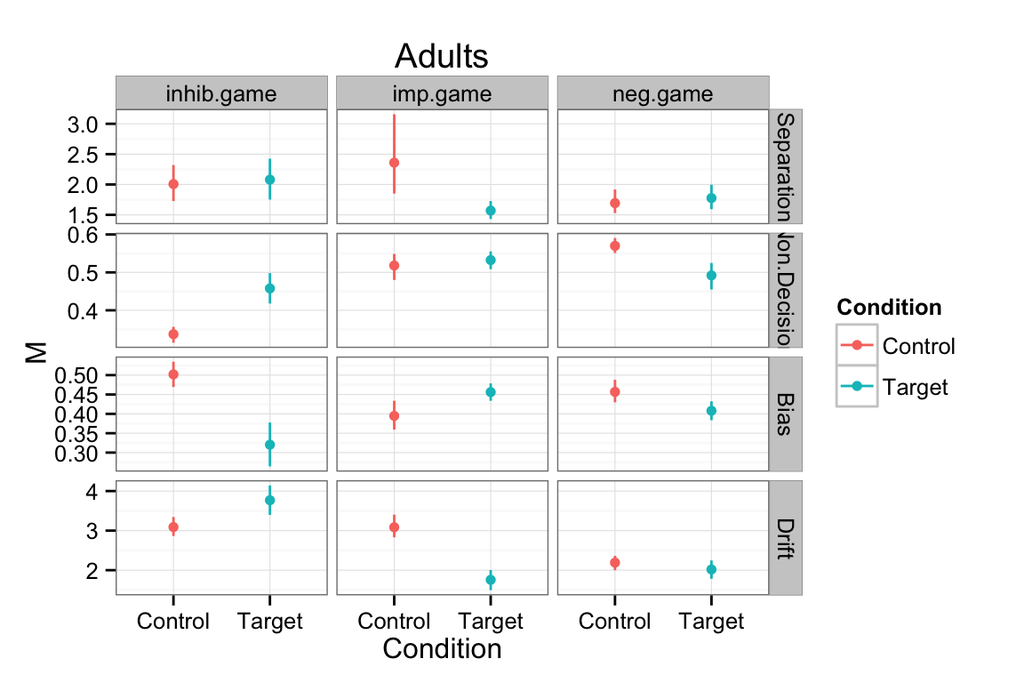

```r
sub.pars <- sub.pars %>%
  mutate(Condition = ifelse(Trial.Type == "control" | Trial.Type == "positive" | Trial.Type == "unambiguous", "Control", "Target"),
         Game = ifelse(Trial.Type == "control" | Trial.Type == "inhib", "inhib.game", ifelse(Trial.Type == "positive" | Trial.Type == "negative", "neg.game", "imp.game")))

sub.pars$Separation <- as.numeric(sub.pars$Separation)
sub.pars$Non.Decision <- as.numeric(sub.pars$Non.Decision)
sub.pars$Bias <- as.numeric(sub.pars$Bias)
sub.pars$Drift <- as.numeric(sub.pars$Drift)

sub.pars.ms <- sub.pars %>%
  gather(Param, Value, Separation:Drift) %>%
  group_by(Age, Modality, Condition, Game, Param) %>%
  summarise(M = mean(Value),
            cih = ci.high(Value),
            cil = ci.low(Value))
sub.pars.ms$Game <- factor(sub.pars.ms$Game, levels = c("inhib.game", "imp.game", "neg.game"))
sub.pars.ms$AgeModality <- paste(sub.pars.ms$Age, sub.pars.ms$Modality, sep = "_")

qplot(data = subset(sub.pars.ms, Age == "adults"), x = Condition, color = Condition,
      y = M, ymax=cih, ymin=cil,
      geom = "pointrange", position = position_dodge(.1)) +
  facet_grid(Param ~ Game, scales = "free") +
  ggtitle("Adults") +
  theme_bw()
```

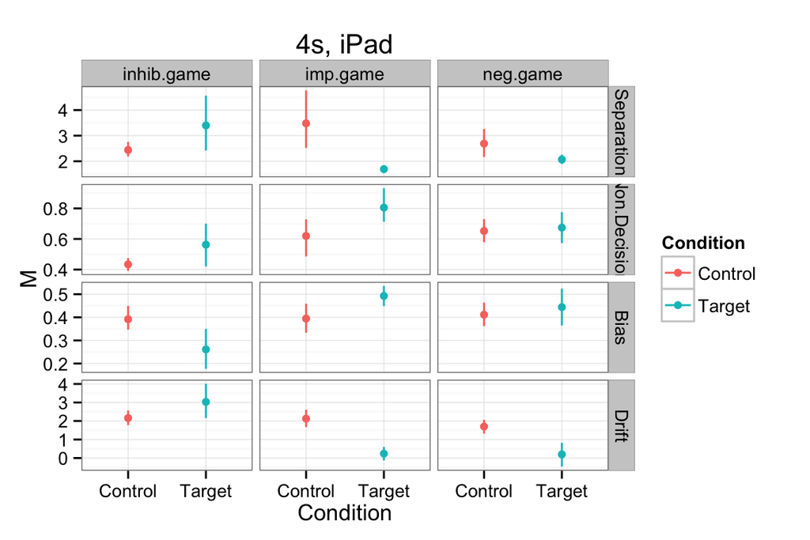

```r
qplot(data = subset(sub.pars.ms, Age == "4" & Modality == "iPad"), x = Condition, color = Condition,
      y = M, ymax=cih, ymin=cil,
      geom = "pointrange", position = position_dodge(.1)) +
  facet_grid(Param ~ Game, scales = "free") +
  ggtitle("4s, iPad") +
  theme_bw()
```

[figure not shown]

```r
qplot(data = subset(sub.pars.ms, Age == "4" & Modality == "computer"), x = Condition, color = Condition,
      y = M, ymax=cih, ymin=cil,
      geom = "pointrange", position = position_dodge(.1)) +
  facet_grid(Param ~ Game, scales = "free") +
  ggtitle("4s, iPad") +
  theme_bw()
```

[figure not shown]

```r
qplot(data = subset(sub.pars.ms, Age == "5" & Modality == "computer"), x = Condition, color = Condition,
      y = M, ymax=cih, ymin=cil,
      geom = "pointrange", position = position_dodge(.1)) +
  facet_grid(Param ~ Game, scales = "free") +
  ggtitle("5s, iPad") +
  theme_bw()
```

[figure not shown]

```r
qplot(data = subset(sub.pars.ms, Age == "6" & Modality == "computer"), x = Condition, color = Condition,
      y = M, ymax=cih, ymin=cil,
      geom = "pointrange", position = position_dodge(.1)) +
  facet_grid(Param ~ Game, scales = "free") +
  ggtitle("6s, iPad") +
  theme_bw()
```

It looks like performance on these games is driven by different processes in both adults and children:

For adults computer vs. 4s iPad: - The difference between conditions in the inhibition game is driven largely by the stronger bias towards the incorrect (lower) boundary in the target condition.  
- In the implicatures game, the control condition has a higher separation boundary (e.g. more conservative decision criteria?) but also a higher drift rate; note that this could explain the similar RTs in these two conditions.  
- In the negation game, it looks like the two conditions (positive v. negative sentences) are really similar, except for kids, where the drift rate is much lower in the target condition (i.e. negative sentences). Note that this looks like the most striking difference between adults and kids, except for main effects (e.g. kids have higher separation boundaries, longer non-decision times, and slower drift rates, consistent with past work)

### Parameter Plot 2 (less terrible?):

These plots are a nightmare.

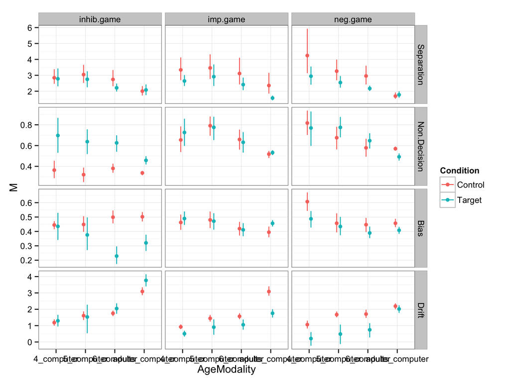

```r
qplot(data = filter(sub.pars.ms, Modality == "computer"), x = AgeModality, color = Condition,
      y = M, ymax=cih, ymin=cil,
      geom = "pointrange", position = position_dodge(.25)) +
  facet_grid(Param ~ Game, scales = "free") +
  theme_bw()
```

### Plot diffusion process:

We can also take these parameters and visualize the actual diffusion process for each game/condition/age group:

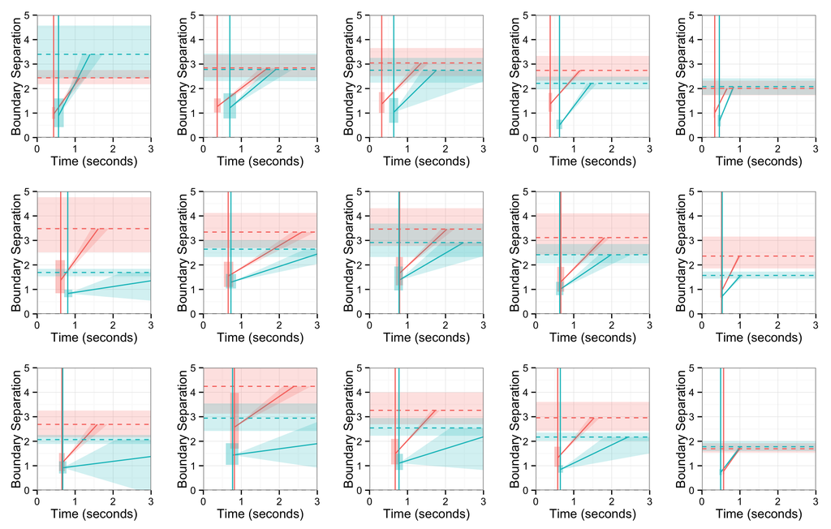

```r
#Visualize diffusion process for each game & condition
games <- c("inhib.game", "imp.game", "neg.game")
agemodality <- unique(sub.pars.ms$AgeModality)
p <- list()

x <- 3
y <- 5

for (a in 1:length(agemodality)) {
  for (g in 1:length(games)) {
    params <- sub.pars.ms %>%
      subset(Game == games[g] & AgeModality == agemodality[a]) %>%
      gather(Name, Value, M:cil) %>%
      unite(Stats, Param, Name) %>%
      spread(Stats, Value)
    params$yint_M = (params$Bias_M*params$Separation_M) - (params$Drift_M*params$Non.Decision_M)
    params$yint_cih = (params$Bias_M*params$Separation_M) - (params$Drift_cih*params$Non.Decision_M)
    params$yint_cil = (params$Bias_M*params$Separation_M) - (params$Drift_cil*params$Non.Decision_M)

    drift_ribbon <- data.frame(xvals = c(params$Non.Decision_M, #non-decision time
                                         (params$Separation_M - params$yint_cih) / params$Drift_cih, #Point where high drift line hits separation boundary
                                         (params$Separation_M - params$yint_M) / params$Drift_M, #Point where drift line hits separation boundary
                                         ifelse(params$Drift_cil > 0, (params$Separation_M - params$yint_cil) / params$Drift_cil, (0 - params$yint_cil) / params$Drift_cil)), #Point where low drift line hits separation boundary or 0
                               ymin = c(params$Bias_M * params$Separation_M, #point where drift starts
                                        params$Drift_cil*((params$Separation_M - params$yint_cih) / params$Drift_cih) + params$yint_cil, #point where low drift is when high drift ends
                                        params$Drift_cil*((params$Separation_M - params$yint_M) / params$Drift_M) + params$yint_cil, #point where low drift is when drift ends
                                        ifelse(params$Drift_cil > 0, params$Separation_M, 0)), #point where low drift ends
                               ymax = c(params$Bias_M * params$Separation_M, #point where drift starts
                                        params$Separation_M, #point where drift ends
                                         params$Separation_M, #point where drift ends
                                        params$Separation_M),#point where drift ends
                               Condition = rep(params$Condition, 4))

    nd_ribbon <- data.frame(xmin = params$Non.Decision_cil,
                            xmax = params$Non.Decision_cih,
                            ymin = rep(params$Bias_cil*params$Separation_cil, 2),
                            ymax = rep(params$Bias_cih*params$Separation_cih, 2),
                            Condition = params$Condition)

    sep_ribbon <- data.frame(xmin = rep(c(0), 2),
                             xmax = rep(x, 2),
                             ymin = params$Separation_cil,
                             ymax = params$Separation_cih,
                             Condition = params$Condition)

    df <- data.frame()

    p[[g + 3*(a-1)]] <- ggplot(df) + coord_cartesian(xlim = c(0, x), ylim = c(0, y)) +
      geom_point() +  theme_bw() +
      geom_segment(data = params,
                   aes(x = Non.Decision_M,
                       xend = (Separation_M - yint_M) / Drift_M,
                       y = Bias_M * Separation_M, yend = Separation_M,
                       color = Condition)) +
      geom_rect(data = nd_ribbon,
                aes(xmin = xmin,
                    xmax = xmax,
                    ymin = ymin,
                    ymax = ymax,
                    fill = Condition),
                alpha=0.2) +
      geom_ribbon(data = drift_ribbon,
                  aes(x = xvals,
                      ymin = ymin,
                      ymax = ymax,
                      fill = Condition),
                  alpha=0.2) +
      geom_rect(data = sep_ribbon,
                aes(xmin = xmin,
                    xmax = xmax,
                    ymin = ymin,
                    ymax = ymax,
                    fill = Condition),
                alpha=0.2) +
      geom_hline(data = params,
                 aes(yintercept = Separation_M, color = Condition),
                 linetype = "dashed") +
      geom_hline(yintercept = 0, linetype = "dashed") +
      geom_vline(data = params,
                 aes(xintercept = Non.Decision_M, color = Condition)) +
      scale_fill_discrete(guide = FALSE) +
      scale_color_discrete(guide = FALSE) +
      xlab("Time (seconds)") + ylab("Boundary Separation") #+ #ggtitle(paste(agemodality[a], "\n", games[g], sep = " "))
  }
}

plotlist <- c(list(p[[4]], p[[1]], p[[7]], p[[10]], p[[13]],
                   p[[5]], p[[2]], p[[8]], p[[11]], p[[14]],
                   p[[6]], p[[3]], p[[9]], p[[12]], p[[15]]), ncol = 5, nrow = 3)
do.call(grid.arrange, plotlist)
```

Pink = control condition and green = target condition (I removed the legend to make more space)

This makes some differences between adults and kids really jump out: first, kids are generally more conservative, as indicated by the higher separation boundary. Particularly striking are the slow drift rates, especially for implicature trials and negation trials. Note that in these two conditions the CIs on the drift rate dip below 0 (i.e. the diffusion process actually heads towards the lower/incorrect boundary). This is consistent with the fact that kids performed around chance on these trials.

For kids comp vs. kids iPad, it looks like there is more variability on the iPad? But in some ways kids on the iPad actually look more like adults: For example, in the inhibition game, kids don’t start to show the inhibition bias until age 6 on the computer, but they show it at 4 on the iPad (this is a little hard to see in these graphs, because of the difference in boundary separation, but is clearer in the previous set of graphs that just compares param values across different agegroups/modalities). And in the implicatures game, kids show the difference in boundary separation on the iPad, but not really on the computer, though it looks like this might be a power issue for the computer data set (?). In other ways, kids on the computer look more like adults on the computer, especially in overall parameter values.

On the negation game, interestingly, there isn’t a ton of developmental change; even 6 year olds are still really struggling on this game, whereas adults have no problem at all. I think this is really interesting, though isn’t clear what the kids are missing.

The problem with this plot is that, when they are all plotted on the same axes (to show the differences between games and agegroups more clearly), the adult plots are hard to read. I’m zooming in here:

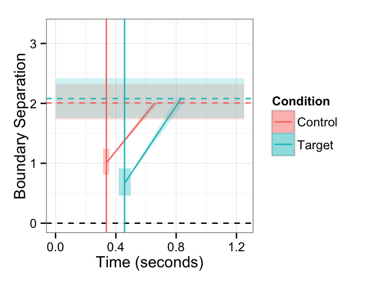

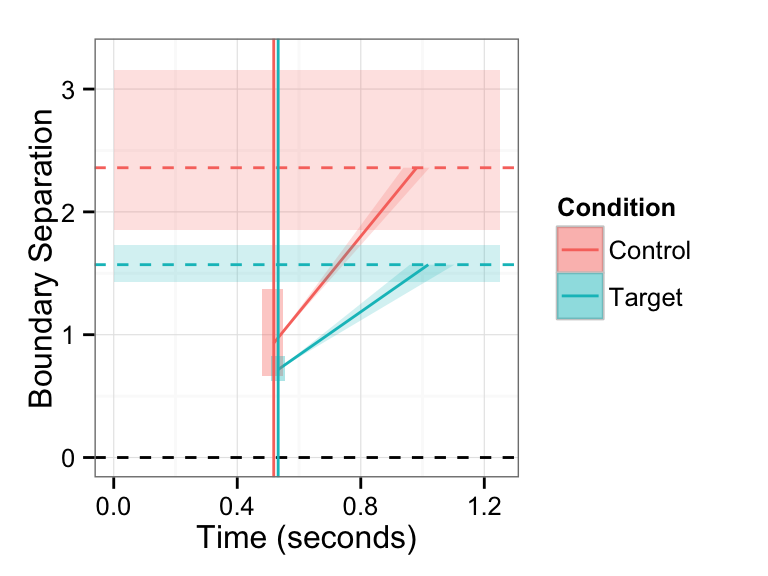

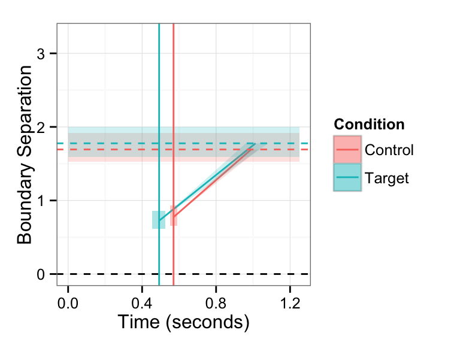

```r
x <- 1.25
y <- 3.25

p <- list()

for (g in 1:length(games)) {
  params <- sub.pars.ms %>%
    subset(Game == games[g] & Age == "adults") %>%
    gather(Name, Value, M:cil) %>%
    unite(Stats, Param, Name) %>%
    spread(Stats, Value)
  params$yint_M = (params$Bias_M*params$Separation_M) - (params$Drift_M*params$Non.Decision_M)
  params$yint_cih = (params$Bias_M*params$Separation_M) - (params$Drift_cih*params$Non.Decision_M)
  params$yint_cil = (params$Bias_M*params$Separation_M) - (params$Drift_cil*params$Non.Decision_M)

  drift_ribbon <- data.frame(xvals = c(params$Non.Decision_M, #non-decision time
                                       (params$Separation_M - params$yint_cih) / params$Drift_cih, #Point where high drift line hits separation boundary
                                       (params$Separation_M - params$yint_cil) / params$Drift_cil), #Point where low drift line hits separation boundary
                             ymin = c(params$Bias_M * params$Separation_M, #point where drift starts
                                      params$Drift_cil*((params$Separation_M - params$yint_cih) / params$Drift_cih) + params$yint_cil, #point where low drift is when high drift ends
                                      params$Separation_M), #point where low drift ends
                             ymax = c(params$Bias_M * params$Separation_M, #point where drift starts
                                      params$Separation_M, #point where drift ends
                                      params$Separation_M),#point where drift ends
                             Condition = rep(params$Condition, 3))

  nd_ribbon <- data.frame(xmin = params$Non.Decision_cil,
                          xmax = params$Non.Decision_cih,
                          ymin = rep(params$Bias_cil*params$Separation_cil, 2),
                          ymax = rep(params$Bias_cih*params$Separation_cih, 2),
                          Condition = params$Condition)

  sep_ribbon <- data.frame(xmin = rep(c(0), 2),
                           xmax = rep(x, 2),
                           ymin = params$Separation_cil,
                           ymax = params$Separation_cih,
                           Condition = params$Condition)

  df <- data.frame()

  p[[g]] <- ggplot(df) + ylim(c(0, y)) + xlim(c(0, x)) +
    geom_point() +  theme_bw() +
    geom_segment(data = params,
                 aes(x = Non.Decision_M,
                     xend = (Separation_M - yint_M) / Drift_M,
                     y = Bias_M * Separation_M, yend = Separation_M,
                     color = Condition)) +
    geom_rect(data = nd_ribbon,
              aes(xmin = xmin,
                  xmax = xmax,
                  ymin = ymin,
                  ymax = ymax,
                  fill = Condition),
              alpha=0.2) +
    geom_ribbon(data = drift_ribbon,
                aes(x = xvals,
                    ymin = ymin,
                    ymax = ymax,
                    fill = Condition),
                alpha=0.2) +
    geom_rect(data = sep_ribbon,
              aes(xmin = xmin,
                  xmax = xmax,
                  ymin = ymin,
                  ymax = ymax,
                  fill = Condition),
              alpha=0.2) +
    geom_hline(data = params,
               aes(yintercept = Separation_M, color = Condition),
               linetype = "dashed") +
    geom_hline(yintercept = 0, linetype = "dashed") +
    geom_vline(data = params,
               aes(xintercept = Non.Decision_M, color = Condition)) +
    #theme(legend.position=c(.9, .8)) +
    xlab("Time (seconds)") + ylab("Boundary Separation") #+ #ggtitle(paste("adults", games[g], sep = " "))
}


print(p)
```

# Statistics

## Adult data t-tests

```r
sub.pars$Age <- factor(sub.pars$Age, levels = c("adults", "4", "5", "6"))
sub.pars$Condition <- factor(sub.pars$Condition)

#adult t tests
inhib.bias <- sub.pars %>%
  filter(Age == "adults", Game == "inhib.game") %>%
  select(Bias, SubID, Condition) %>%
  spread(Condition, Bias)

t.test(inhib.bias$Control, inhib.bias$Target, paired = T)
```

```
##
##  Paired t-test
##
## data:  inhib.bias$Control and inhib.bias$Target
## t = 5.0489, df = 47, p-value = 7.128e-06
## alternative hypothesis: true difference in means is not equal to 0
## 95 percent confidence interval:
##  0.1092425 0.2539601
## sample estimates:
## mean of the differences
##               0.1816013
```

```r
imp.sep <- sub.pars %>%
  filter(Age == "adults", Game == "imp.game") %>%
  select(Separation, SubID, Condition) %>%
  spread(Condition, Separation)

t.test(imp.sep$Control, imp.sep$Target, paired = T)
```

```
##
##  Paired t-test
##
## data:  imp.sep$Control and imp.sep$Target
## t = 2.393, df = 47, p-value = 0.02076
## alternative hypothesis: true difference in means is not equal to 0
## 95 percent confidence interval:
##  0.1257511 1.4527507
## sample estimates:
## mean of the differences
##               0.7892509
```

```r
imp.drift <- sub.pars %>%
  filter(Age == "adults", Game == "imp.game") %>%
  select(Drift, SubID, Condition) %>%
  spread(Condition, Drift)

t.test(imp.drift$Control, imp.drift$Target, paired = T)
```

```
##
##  Paired t-test
##
## data:  imp.drift$Control and imp.drift$Target
## t = 7.3447, df = 47, p-value = 2.458e-09
## alternative hypothesis: true difference in means is not equal to 0
## 95 percent confidence interval:
##  0.9647057 1.6925267
## sample estimates:
## mean of the differences
##                1.328616
```

```r
neg.drift <- sub.pars %>%
  filter(Age == "adults", Game == "neg.game") %>%
  select(Drift, SubID, Condition) %>%
  spread(Condition, Drift)

t.test(neg.drift$Control, neg.drift$Target, paired = T)
```

```
##
##  Paired t-test
##
## data:  neg.drift$Control and neg.drift$Target
## t = 1.1842, df = 47, p-value = 0.2423
## alternative hypothesis: true difference in means is not equal to 0
## 95 percent confidence interval:
##  -0.1210297  0.4673860
## sample estimates:
## mean of the differences
##               0.1731782
```

```r
#Note: Non-decision is sig for negation game (and inhib too, I suspect), but I'm not really sure what to say about this, so I didn't discuss it in the paper.  Maybe we should though?
neg.nd <- sub.pars %>%
  filter(Age == "adults", Game == "neg.game") %>%
  select(Non.Decision, SubID, Condition) %>%
  spread(Condition, Non.Decision)

t.test(neg.nd$Control, neg.nd$Target, paired = T)
```

```
##
##  Paired t-test
##
## data:  neg.nd$Control and neg.nd$Target
## t = 4.7841, df = 47, p-value = 1.738e-05
## alternative hypothesis: true difference in means is not equal to 0
## 95 percent confidence interval:
##  0.04512933 0.11062384
## sample estimates:
## mean of the differences
##              0.07787658
```

## Developmental Change across games

```r
##Inhibition game
inhib <- filter(sub.pars, Modality == "computer" & Game == "inhib.game")

inhib.sep <- lm(Separation ~ Age * Condition, data = inhib)
summary(inhib.sep)
```

```
##
## Call:
## lm(formula = Separation ~ Age * Condition, data = inhib)
##
## Residuals:
##     Min      1Q  Median      3Q     Max
## -1.6091 -0.6786 -0.3543  0.1728  5.4756
##
## Coefficients:
##                      Estimate Std. Error t value Pr(>|t|)
## (Intercept)           2.00695    0.16848  11.912  < 2e-16 ***
## Age4                  0.83733    0.30053   2.786  0.00580 **
## Age5                  1.03924    0.31638   3.285  0.00119 **
## Age6                  0.73443    0.28790   2.551  0.01142 *
## ConditionTarget       0.07312    0.23827   0.307  0.75921
## Age4:ConditionTarget -0.13666    0.42501  -0.322  0.74810
## Age5:ConditionTarget -0.37008    0.44743  -0.827  0.40906
## Age6:ConditionTarget -0.60215    0.40715  -1.479  0.14059
## ---
## Signif. codes:  0 '***' 0.001 '**' 0.01 '*' 0.05 '.' 0.1 ' ' 1
##
## Residual standard error: 1.167 on 220 degrees of freedom
## Multiple R-squared:  0.1011, Adjusted R-squared:  0.07248
## F-statistic: 3.534 on 7 and 220 DF,  p-value: 0.001282
```

```r
inhib.nd <- lm(Non.Decision ~ Age * Condition, data = inhib)
summary(inhib.nd)
```

```
##
## Call:
## lm(formula = Non.Decision ~ Age * Condition, data = inhib)
##
## Residuals:
##      Min       1Q   Median       3Q      Max
## -0.69727 -0.08456 -0.01137  0.08674  0.68546
##
## Coefficients:
##                      Estimate Std. Error t value Pr(>|t|)
## (Intercept)           0.33699    0.02890  11.662  < 2e-16 ***
## Age4                  0.02708    0.05154   0.525  0.59981
## Age5                 -0.01677    0.05426  -0.309  0.75763
## Age6                  0.04338    0.04938   0.879  0.38063
## ConditionTarget       0.12076    0.04086   2.955  0.00346 **
## Age4:ConditionTarget  0.21244    0.07289   2.914  0.00393 **
## Age5:ConditionTarget  0.19670    0.07674   2.563  0.01103 *
## Age6:ConditionTarget  0.12472    0.06983   1.786  0.07546 .
## ---
## Signif. codes:  0 '***' 0.001 '**' 0.01 '*' 0.05 '.' 0.1 ' ' 1
##
## Residual standard error: 0.2002 on 220 degrees of freedom
## Multiple R-squared:  0.3113, Adjusted R-squared:  0.2894
## F-statistic:  14.2 on 7 and 220 DF,  p-value: 3.455e-15
```

```r
inhib.bias <- lm(Bias ~ Age * Condition, data = inhib)
summary(inhib.bias)
```

```
##
## Call:
## lm(formula = Bias ~ Age * Condition, data = inhib)
##
## Residuals:
##      Min       1Q   Median       3Q      Max
## -0.34136 -0.11087 -0.02399  0.07620  0.62220
##
## Coefficients:
##                       Estimate Std. Error t value Pr(>|t|)
## (Intercept)           0.501947   0.024357  20.608  < 2e-16 ***
## Age4                 -0.057117   0.043446  -1.315  0.18999
## Age5                 -0.053506   0.045738  -1.170  0.24333
## Age6                 -0.002986   0.041621  -0.072  0.94288
## ConditionTarget      -0.181601   0.034445  -5.272 3.22e-07 ***
## Age4:ConditionTarget  0.172055   0.061442   2.800  0.00556 **
## Age5:ConditionTarget  0.109075   0.064683   1.686  0.09316 .
## Age6:ConditionTarget -0.088460   0.058860  -1.503  0.13430
## ---
## Signif. codes:  0 '***' 0.001 '**' 0.01 '*' 0.05 '.' 0.1 ' ' 1
##
## Residual standard error: 0.1687 on 220 degrees of freedom
## Multiple R-squared:  0.2325, Adjusted R-squared:  0.2081
## F-statistic:  9.52 on 7 and 220 DF,  p-value: 2.553e-10
```

```r
inhib.drift <- lm(Drift ~ Age * Condition, data = inhib)
summary(inhib.drift)
```

```
##
## Call:
## lm(formula = Drift ~ Age * Condition, data = inhib)
##
## Residuals:
##     Min      1Q  Median      3Q     Max
## -7.0820 -0.5147 -0.0507  0.5615  2.7276
##
## Coefficients:
##                      Estimate Std. Error t value Pr(>|t|)
## (Intercept)            3.0897     0.1492  20.710  < 2e-16 ***
## Age4                  -1.9054     0.2661  -7.160 1.19e-11 ***
## Age5                  -1.4801     0.2802  -5.283 3.05e-07 ***
## Age6                  -1.3371     0.2549  -5.245 3.66e-07 ***
## ConditionTarget        0.6784     0.2110   3.216   0.0015 **
## Age4:ConditionTarget  -0.5677     0.3763  -1.508   0.1329
## Age5:ConditionTarget  -0.7572     0.3962  -1.911   0.0573 .
## Age6:ConditionTarget  -0.3864     0.3605  -1.072   0.2850
## ---
## Signif. codes:  0 '***' 0.001 '**' 0.01 '*' 0.05 '.' 0.1 ' ' 1
##
## Residual standard error: 1.034 on 220 degrees of freedom
## Multiple R-squared:  0.4737, Adjusted R-squared:  0.457
## F-statistic: 28.29 on 7 and 220 DF,  p-value: < 2.2e-16
```

```r
##Implicature game
imp <- filter(sub.pars, Modality == "computer" & Game == "imp.game")

imp.sep <- lm(Separation ~ Age * Condition, data = imp)
summary(imp.sep)
```

```
##
## Call:
## lm(formula = Separation ~ Age * Condition, data = imp)
##
## Residuals:
##     Min      1Q  Median      3Q     Max
## -1.9628 -0.7702 -0.3558  0.0834 13.6765
##
## Coefficients:
##                      Estimate Std. Error t value Pr(>|t|)
## (Intercept)           2.35938    0.23878   9.881   <2e-16 ***
## Age4                  0.98229    0.42593   2.306   0.0220 *
## Age5                  1.10340    0.44840   2.461   0.0146 *
## Age6                  0.75549    0.40803   1.852   0.0654 .
## ConditionTarget      -0.78925    0.33769  -2.337   0.0203 *
## Age4:ConditionTarget  0.09033    0.60236   0.150   0.8809
## Age5:ConditionTarget  0.23986    0.63413   0.378   0.7056
## Age6:ConditionTarget  0.08951    0.57704   0.155   0.8769
## ---
## Signif. codes:  0 '***' 0.001 '**' 0.01 '*' 0.05 '.' 0.1 ' ' 1
##
## Residual standard error: 1.654 on 220 degrees of freedom
## Multiple R-squared:  0.1282, Adjusted R-squared:  0.1005
## F-statistic: 4.623 on 7 and 220 DF,  p-value: 7.591e-05
```

```r
imp.nd <- lm(Non.Decision ~ Age * Condition, data = imp)
summary(imp.nd)
```

```
##
## Call:
## lm(formula = Non.Decision ~ Age * Condition, data = imp)
##
## Residuals:
##      Min       1Q   Median       3Q      Max
## -0.77551 -0.07181  0.01155  0.10900  0.64495
##
## Coefficients:
##                      Estimate Std. Error t value Pr(>|t|)
## (Intercept)           0.51809    0.03126  16.573  < 2e-16 ***
## Age4                  0.13634    0.05576   2.445  0.01527 *
## Age5                  0.27323    0.05870   4.654 5.62e-06 ***
## Age6                  0.14074    0.05342   2.635  0.00902 **
## ConditionTarget       0.01435    0.04421   0.325  0.74575
## Age4:ConditionTarget  0.05741    0.07886   0.728  0.46738
## Age5:ConditionTarget -0.03016    0.08302  -0.363  0.71674
## Age6:ConditionTarget -0.04156    0.07555  -0.550  0.58278
## ---
## Signif. codes:  0 '***' 0.001 '**' 0.01 '*' 0.05 '.' 0.1 ' ' 1
##
## Residual standard error: 0.2166 on 220 degrees of freedom
## Multiple R-squared:  0.175,  Adjusted R-squared:  0.1488
## F-statistic: 6.668 on 7 and 220 DF,  p-value: 3.648e-07
```

```r
imp.bias <- lm(Bias ~ Age * Condition, data = imp)
summary(imp.bias)
```

```
##
## Call:
## lm(formula = Bias ~ Age * Condition, data = imp)
##
## Residuals:
##      Min       1Q   Median       3Q      Max
## -0.30485 -0.07647 -0.00793  0.06804  0.47948
##
## Coefficients:
##                      Estimate Std. Error t value Pr(>|t|)
## (Intercept)           0.39471    0.01734  22.760   <2e-16 ***
## Age4                  0.06755    0.03093   2.184   0.0300 *
## Age5                  0.08521    0.03257   2.617   0.0095 **
## Age6                  0.02477    0.02963   0.836   0.4042
## ConditionTarget       0.06142    0.02453   2.504   0.0130 *
## Age4:ConditionTarget -0.03419    0.04375  -0.782   0.4353
## Age5:ConditionTarget -0.07003    0.04606  -1.521   0.1298
## Age6:ConditionTarget -0.06978    0.04191  -1.665   0.0973 .
## ---
## Signif. codes:  0 '***' 0.001 '**' 0.01 '*' 0.05 '.' 0.1 ' ' 1
##
## Residual standard error: 0.1202 on 220 degrees of freedom
## Multiple R-squared:  0.07449,    Adjusted R-squared:  0.04504
## F-statistic:  2.53 on 7 and 220 DF,  p-value: 0.01602
```

```r
imp.drift <- lm(Drift ~ Age * Condition, data = imp)
summary(imp.drift)
```

```
##
## Call:
## lm(formula = Drift ~ Age * Condition, data = imp)
##
## Residuals:
##     Min      1Q  Median      3Q     Max
## -2.4440 -0.4415 -0.0023  0.3773  5.1855
##
## Coefficients:
##                      Estimate Std. Error t value Pr(>|t|)
## (Intercept)            3.0851     0.1161  26.564  < 2e-16 ***
## Age4                  -2.1593     0.2072 -10.423  < 2e-16 ***
## Age5                  -1.6397     0.2181  -7.518 1.39e-12 ***
## Age6                  -1.5149     0.1985  -7.633 6.90e-13 ***
## ConditionTarget       -1.3286     0.1642  -8.089 4.02e-14 ***
## Age4:ConditionTarget   0.9093     0.2930   3.104  0.00216 **
## Age5:ConditionTarget   0.7896     0.3084   2.560  0.01113 *
## Age6:ConditionTarget   0.8104     0.2807   2.887  0.00427 **
## ---
## Signif. codes:  0 '***' 0.001 '**' 0.01 '*' 0.05 '.' 0.1 ' ' 1
##
## Residual standard error: 0.8046 on 220 degrees of freedom
## Multiple R-squared:  0.5292, Adjusted R-squared:  0.5142
## F-statistic: 35.32 on 7 and 220 DF,  p-value: < 2.2e-16
```

```r
##Negation game
neg <- filter(sub.pars, Modality == "computer" & Game == "neg.game")

neg.sep <- lm(Separation ~ Age * Condition, data = neg)
summary(neg.sep)
```

```
##
## Call:
## lm(formula = Separation ~ Age * Condition, data = neg)
##
## Residuals:
##     Min      1Q  Median      3Q     Max
## -2.4640 -0.5486 -0.2454  0.1207 13.8756
##
## Coefficients:
##                      Estimate Std. Error t value Pr(>|t|)
## (Intercept)            1.6934     0.2081   8.139 2.93e-14 ***
## Age4                   2.5489     0.3711   6.868 6.57e-11 ***
## Age5                   1.5678     0.3907   4.013 8.23e-05 ***
## Age6                   1.2644     0.3555   3.556  0.00046 ***
## ConditionTarget        0.0835     0.2942   0.284  0.77684
## Age4:ConditionTarget  -1.3823     0.5249  -2.634  0.00905 **
## Age5:ConditionTarget  -0.8012     0.5525  -1.450  0.14847
## Age6:ConditionTarget  -0.8702     0.5028  -1.731  0.08492 .
## ---
## Signif. codes:  0 '***' 0.001 '**' 0.01 '*' 0.05 '.' 0.1 ' ' 1
##
## Residual standard error: 1.441 on 220 degrees of freedom
## Multiple R-squared:  0.2424, Adjusted R-squared:  0.2183
## F-statistic: 10.05 on 7 and 220 DF,  p-value: 6.792e-11
```

```r
neg.nd <- lm(Non.Decision ~ Age * Condition , data = neg)
summary(neg.nd)
```

```
##
## Call:
## lm(formula = Non.Decision ~ Age * Condition, data = neg)
##
## Residuals:
##      Min       1Q   Median       3Q      Max
## -0.67494 -0.08367  0.00119  0.09363  0.77400
##
## Coefficients:
##                       Estimate Std. Error t value Pr(>|t|)
## (Intercept)           0.569885   0.031214  18.257  < 2e-16 ***
## Age4                  0.247168   0.055679   4.439 1.43e-05 ***
## Age5                  0.105486   0.058615   1.800   0.0733 .
## Age6                  0.008596   0.053339   0.161   0.8721
## ConditionTarget      -0.077877   0.044143  -1.764   0.0791 .
## Age4:ConditionTarget  0.030349   0.078742   0.385   0.7003
## Age5:ConditionTarget  0.177547   0.082895   2.142   0.0333 *
## Age6:ConditionTarget  0.146533   0.075432   1.943   0.0533 .
## ---
## Signif. codes:  0 '***' 0.001 '**' 0.01 '*' 0.05 '.' 0.1 ' ' 1
##
## Residual standard error: 0.2163 on 220 degrees of freedom
## Multiple R-squared:  0.2138, Adjusted R-squared:  0.1887
## F-statistic: 8.544 on 7 and 220 DF,  p-value: 2.961e-09
```

```r
neg.bias <- lm(Bias ~ Age * Condition, data = neg)
summary(neg.bias)
```

```
##
## Call:
## lm(formula = Bias ~ Age * Condition, data = neg)
##
## Residuals:
##      Min       1Q   Median       3Q      Max
## -0.33934 -0.07768 -0.01589  0.08390  0.37746
##
## Coefficients:
##                        Estimate Std. Error t value Pr(>|t|)
## (Intercept)           0.4567825  0.0176624  25.862  < 2e-16 ***
## Age4                  0.1502314  0.0315056   4.768 3.38e-06 ***
## Age5                 -0.0000374  0.0331674  -0.001   0.9991
## Age6                 -0.0097647  0.0301816  -0.324   0.7466
## ConditionTarget      -0.0487843  0.0249784  -1.953   0.0521 .
## Age4:ConditionTarget -0.0707291  0.0445557  -1.587   0.1139
## Age5:ConditionTarget  0.0262859  0.0469057   0.560   0.5758
## Age6:ConditionTarget -0.0091582  0.0426832  -0.215   0.8303
## ---
## Signif. codes:  0 '***' 0.001 '**' 0.01 '*' 0.05 '.' 0.1 ' ' 1
##
## Residual standard error: 0.1224 on 220 degrees of freedom
## Multiple R-squared:  0.1866, Adjusted R-squared:  0.1607
## F-statistic: 7.211 on 7 and 220 DF,  p-value: 8.945e-08
```

```r
neg.drift <- lm(Drift ~ Age * Condition, data = neg)
summary(neg.drift)
```

```
##
## Call:
## lm(formula = Drift ~ Age * Condition, data = neg)
##
## Residuals:
##     Min      1Q  Median      3Q     Max
## -4.0326 -0.3831  0.1278  0.4871  2.4574
##
## Coefficients:
##                      Estimate Std. Error t value Pr(>|t|)
## (Intercept)            2.1913     0.1249  17.540  < 2e-16 ***
## Age4                  -1.1301     0.2229  -5.071 8.39e-07 ***
## Age5                  -0.5169     0.2346  -2.203  0.02861 *
## Age6                  -0.4836     0.2135  -2.265  0.02448 *
## ConditionTarget       -0.1732     0.1767  -0.980  0.32808
## Age4:ConditionTarget  -0.6790     0.3152  -2.154  0.03229 *
## Age5:ConditionTarget  -1.0172     0.3318  -3.066  0.00244 **
## Age6:ConditionTarget  -0.7905     0.3019  -2.618  0.00945 **
## ---
## Signif. codes:  0 '***' 0.001 '**' 0.01 '*' 0.05 '.' 0.1 ' ' 1
##
## Residual standard error: 0.8656 on 220 degrees of freedom
## Multiple R-squared:  0.4043, Adjusted R-squared:  0.3854
## F-statistic: 21.33 on 7 and 220 DF,  p-value: < 2.2e-16
```

## General Developmental Change

```r
#Look at changes in paramaters in general across age:
sep.model <- lm(Separation ~ Age, data = sub.pars)
summary(sep.model)
```

```
##
## Call:
## lm(formula = Separation ~ Age, data = sub.pars)
##
## Residuals:
##     Min      1Q  Median      3Q     Max
## -1.9565 -0.7013 -0.4029  0.0986 15.2194
##
## Coefficients:
##             Estimate Std. Error t value Pr(>|t|)
## (Intercept)  1.91448    0.08791  21.778  < 2e-16 ***
## Age4         0.98408    0.12952   7.598 8.47e-14 ***
## Age5         1.08157    0.16508   6.552 1.02e-10 ***
## Age6         0.68764    0.15022   4.578 5.46e-06 ***
## ---
## Signif. codes:  0 '***' 0.001 '**' 0.01 '*' 0.05 '.' 0.1 ' ' 1
##
## Residual standard error: 1.492 on 794 degrees of freedom
## Multiple R-squared:  0.08655,    Adjusted R-squared:  0.08309
## F-statistic: 25.08 on 3 and 794 DF,  p-value: 1.656e-15
```

```r
nd.model <- lm(Non.Decision ~ Age, data = sub.pars)
summary(nd.model)
```

```
##
## Call:
## lm(formula = Non.Decision ~ Age, data = sub.pars)
##
## Residuals:
##      Min       1Q   Median       3Q      Max
## -0.66252 -0.14007  0.01037  0.13667  0.94127
##
## Coefficients:
##             Estimate Std. Error t value Pr(>|t|)
## (Intercept)  0.48453    0.01422  34.081  < 2e-16 ***
## Age4         0.16525    0.02095   7.889 1.01e-14 ***
## Age5         0.17800    0.02670   6.667 4.88e-11 ***
## Age6         0.10252    0.02429   4.220 2.73e-05 ***
## ---
## Signif. codes:  0 '***' 0.001 '**' 0.01 '*' 0.05 '.' 0.1 ' ' 1
##
## Residual standard error: 0.2413 on 794 degrees of freedom
## Multiple R-squared:  0.09063,    Adjusted R-squared:  0.0872
## F-statistic: 26.38 on 3 and 794 DF,  p-value: 2.855e-16
```

```r
bias.model <- lm(Bias ~ Age, data = sub.pars)
summary(bias.model)
```

```
##
## Call:
## lm(formula = Bias ~ Age, data = sub.pars)
##
## Residuals:
##      Min       1Q   Median       3Q      Max
## -0.38860 -0.09181 -0.00086  0.08641  0.55368
##
## Coefficients:
##              Estimate Std. Error t value Pr(>|t|)
## (Intercept)  0.422985   0.009057  46.701   <2e-16 ***
## Age4         0.023700   0.013344   1.776   0.0761 .
## Age5         0.021444   0.017008   1.261   0.2077
## Age6        -0.023895   0.015477  -1.544   0.1230
## ---
## Signif. codes:  0 '***' 0.001 '**' 0.01 '*' 0.05 '.' 0.1 ' ' 1
##
## Residual standard error: 0.1537 on 794 degrees of freedom
## Multiple R-squared:  0.01308,    Adjusted R-squared:  0.009354
## F-statistic: 3.508 on 3 and 794 DF,  p-value: 0.01502
```

```r
drift.model <- lm(Drift ~ Age, data = sub.pars)
summary(drift.model)
```

```
##
## Call:
## lm(formula = Drift ~ Age, data = sub.pars)
##
## Residuals:
##     Min      1Q  Median      3Q     Max
## -6.8263 -0.5960 -0.0474  0.5877  7.4543
##
## Coefficients:
##             Estimate Std. Error t value Pr(>|t|)
## (Intercept)  2.65146    0.06912  38.362   <2e-16 ***
## Age4        -1.45813    0.10183 -14.319   <2e-16 ***
## Age5        -1.37638    0.12979 -10.605   <2e-16 ***
## Age6        -1.17295    0.11811  -9.931   <2e-16 ***
## ---
## Signif. codes:  0 '***' 0.001 '**' 0.01 '*' 0.05 '.' 0.1 ' ' 1
##
## Residual standard error: 1.173 on 794 degrees of freedom
## Multiple R-squared:  0.2406, Adjusted R-squared:  0.2377
## F-statistic: 83.84 on 3 and 794 DF,  p-value: < 2.2e-16
```

```r
#Look at continuous across age group, just children
sub.pars.cont <- filter(sub.pars, Age != "adults")
sub.pars.cont$Age <- as.numeric(as.character(sub.pars.cont$Age))

cont.sep.model <- lm(Separation ~ Age, data = sub.pars.cont)
summary(cont.sep.model)
```

```
##
## Call:
## lm(formula = Separation ~ Age, data = sub.pars.cont)
##
## Residuals:
##     Min      1Q  Median      3Q     Max
## -2.0001 -0.8223 -0.4724  0.1262 15.1758
##
## Coefficients:
##             Estimate Std. Error t value Pr(>|t|)
## (Intercept)  3.47925    0.40346   8.623   <2e-16 ***
## Age         -0.13427    0.08254  -1.627    0.104
## ---
## Signif. codes:  0 '***' 0.001 '**' 0.01 '*' 0.05 '.' 0.1 ' ' 1
##
## Residual standard error: 1.605 on 508 degrees of freedom
## Multiple R-squared:  0.005182,   Adjusted R-squared:  0.003224
## F-statistic: 2.646 on 1 and 508 DF,  p-value: 0.1044
```

```r
cont.nd.model <- lm(Non.Decision ~ Age, data = sub.pars.cont)
summary(cont.nd.model)
```

```
##
## Call:
## lm(formula = Non.Decision ~ Age, data = sub.pars.cont)
##
## Residuals:
##      Min       1Q   Median       3Q      Max
## -0.65760 -0.20944  0.01505  0.18325  0.93345
##
## Coefficients:
##             Estimate Std. Error t value Pr(>|t|)
## (Intercept)  0.77305    0.07200  10.737   <2e-16 ***
## Age         -0.02886    0.01473  -1.959   0.0506 .
## ---
## Signif. codes:  0 '***' 0.001 '**' 0.01 '*' 0.05 '.' 0.1 ' ' 1
##
## Residual standard error: 0.2863 on 508 degrees of freedom
## Multiple R-squared:  0.007502,   Adjusted R-squared:  0.005548
## F-statistic:  3.84 on 1 and 508 DF,  p-value: 0.0506
```

```r
cont.bias.model <- lm(Bias ~ Age, data = sub.pars.cont)
summary(cont.bias.model)
```

```
##
## Call:
## lm(formula = Bias ~ Age, data = sub.pars.cont)
##
## Residuals:
##      Min       1Q   Median       3Q      Max
## -0.39242 -0.10577 -0.00192  0.09449  0.57018
##
## Coefficients:
##              Estimate Std. Error t value Pr(>|t|)
## (Intercept)  0.540803   0.040781  13.261  < 2e-16 ***
## Age         -0.022574   0.008343  -2.706  0.00704 **
## ---
## Signif. codes:  0 '***' 0.001 '**' 0.01 '*' 0.05 '.' 0.1 ' ' 1
##
## Residual standard error: 0.1622 on 508 degrees of freedom
## Multiple R-squared:  0.01421,    Adjusted R-squared:  0.01227
## F-statistic: 7.321 on 1 and 508 DF,  p-value: 0.007043
```

```r
cont.drift.model <- lm(Drift ~ Age, data = sub.pars.cont)
summary(cont.drift.model)
```

```
##
## Call:
## lm(formula = Drift ~ Age, data = sub.pars.cont)
##
## Residuals:
##     Min      1Q  Median      3Q     Max
## -6.8729 -0.4733 -0.0155  0.5758  7.4651
##
## Coefficients:
##             Estimate Std. Error t value Pr(>|t|)
## (Intercept)  0.62600    0.29243   2.141   0.0328 *
## Age          0.13914    0.05982   2.326   0.0204 *
## ---
## Signif. codes:  0 '***' 0.001 '**' 0.01 '*' 0.05 '.' 0.1 ' ' 1
##
## Residual standard error: 1.163 on 508 degrees of freedom
## Multiple R-squared:  0.01054,    Adjusted R-squared:  0.008588
## F-statistic: 5.409 on 1 and 508 DF,  p-value: 0.02043
```